# Day 5 Homework

0. Reload your data, and re-use the code you already have for getting things formatted nicely (columns renamed, factors relabeled, etc.)

```r
usePackage <- function(p) {
    if (!is.element(p, installed.packages()[,1]))
        install.packages(p, dep = TRUE)
    require(p, character.only = TRUE)
}
usePackage('dplyr')
Mortality <- bind_rows("10_2" = read.csv(unz("Data/Morticd10_part2.zip","Morticd10_part2")),
                       "10_1" = read.csv(unz("Data/Morticd10_part1.zip","Morticd10_part1")),
                       "9" = read.csv(unz("Data/morticd9.zip","Morticd9")),
                       "8" = read.csv(unz("Data/morticd08.zip","Morticd8")),
                       "7" = read.csv(unz("Data/morticd07.zip","MortIcd7")),
                       .id = "ICD")
Mortality$ICD <- factor(as.factor(Mortality$ICD), c("10_2","10_1","9","8","7"))

Mortality$Sex <- factor(Mortality$Sex, labels = c("Male","Female", "Unspecified"))

summary(Mortality$Sex)
```

```
##        Male      Female Unspecified
##     2464940     2338644       17032
```

```r
#Mortality$Sex[Mortality$Sex=="Missing",] <- NA
#xtabs(~Mortality$Sex + Mortality$SexNA, na.action = na.pass, exclude = NULL)

Population <- read.csv(unzip("Data/Pop.zip"))
```

1. Aggregate (e.g., get mean/median/max/something) of some numerical variable, over one or more factors. Use `group_by()` plus `summarize()` from the `dplyr` package.

```r
#Commands were taking long or RStudio was freezing, so I took a random sample out of my data for the purposes of this homework.

MortalitySample <- Mortality [sample(nrow(Mortality), nrow(Mortality)/1000),]
str(MortalitySample)
```

```
## 'data.frame':    4820 obs. of  40 variables:
##  $ ICD       : Factor w/ 5 levels "10_2","10_1",..: 1 3 1 1 3 1 3 5 1 1 ...
##  $ Country   : int  2460 2140 4085 2470 5150 2020 3160 5150 3300 2070 ...
##  $ Admin1    : int  NA NA NA NA NA NA NA NA NA NA ...
##  $ SubDiv    : chr  "" "" "" "" ...
##  $ Year      : int  2005 1993 2014 2008 1998 2011 1992 1961 2010 2008 ...
##  $ List      : chr  "104" "09A" "104" "104" ...
##  $ Cause     : chr  "Q639" "B024" "W848" "K319" ...
##  $ Sex       : Factor w/ 3 levels "Male","Female",..: 2 1 1 1 1 2 1 1 1 1 ...
##  $ Frmat     : int  0 1 0 0 1 0 1 1 0 0 ...
##  $ IM_Frmat  : int  1 1 1 1 1 1 1 8 1 1 ...
##  $ Deaths1   : int  1 0 2 8 2 313 5 30 1 73 ...
##  $ Deaths2   : int  1 0 0 0 0 2 0 0 0 10 ...
##  $ Deaths3   : int  0 0 0 0 0 0 0 1 0 2 ...
##  $ Deaths4   : int  0 0 0 0 0 0 0 0 0 2 ...
```

[output cut: 26 more lines]

```r
summarize(group_by(MortalitySample, Country, Sex, Cause), mean = mean(Deaths1))
```

```
## Source: local data frame [4,783 x 4]
## Groups: Country, Sex [?]
##
##    Country    Sex Cause  mean
##      <int> <fctr> <chr> <dbl>
## 1     1060 Female   I51    12
## 2     1125   Male  A059    44
## 3     1125   Male  A113     0
## 4     1125   Male  A136  8415
## 5     1125   Male  A137 16018
## 6     1125   Male   A24     1
## 7     1125   Male   A87    55
## 8     1125   Male  B154     0
## 9     1125   Male  B330     1
## 10    1125   Male   F66     1
## # ... with 4,773 more rows
```

2. Run TWO DIFFERENT simple analyses or statistical tests, such as linear regression (`lm()`), logistic regression (`glm()`), correlation test (`cor.test()`), t-test (`t.test()`), or non-parametric tests (e.g., `wilcox.test()`). For each of these:
- Describe why you are doing this analysis, i.e., what question is it answering?
- I won’t judge you on statistical expertise! (though I will make comments if I think I can be helpful)
- Report some key statistics from the analysis, using **inline** code. HINT: outside of an R code chunk, use format.

```r
#I am adding-up infant deaths at all ages
  #?grep
  #?rowsum

summary(MortalitySample[,grep("IM_Deaths", names(MortalitySample))])
```

```
##    IM_Deaths1         IM_Deaths2         IM_Deaths3
##  Min.   :    0.00   Min.   :  0.0000   Min.   :  0.0000
##  1st Qu.:    0.00   1st Qu.:  0.0000   1st Qu.:  0.0000
##  Median :    0.00   Median :  0.0000   Median :  0.0000
##  Mean   :   24.05   Mean   :  0.7668   Mean   :  0.4409
##  3rd Qu.:    0.00   3rd Qu.:  0.0000   3rd Qu.:  0.0000
##  Max.   :62394.00   Max.   :451.0000   Max.   :113.0000
##  NA's   :15         NA's   :1364       NA's   :1243
##    IM_Deaths4
##  Min.   :   0.000
##  1st Qu.:   0.000
##  Median :   0.000
##  Mean   :   2.374
##  3rd Qu.:   0.000
##  Max.   :1708.000
##  NA's   :1243
```

```r
MortalitySample$InfantDeaths <- MortalitySample$IM_Deaths1+ MortalitySample$IM_Deaths2+ MortalitySample$IM_Deaths3+ MortalitySample$IM_Deaths4

summary(MortalitySample[,c(grep("IM_Deaths", names(MortalitySample)),41)])
```

```
##    IM_Deaths1         IM_Deaths2         IM_Deaths3
##  Min.   :    0.00   Min.   :  0.0000   Min.   :  0.0000
##  1st Qu.:    0.00   1st Qu.:  0.0000   1st Qu.:  0.0000
##  Median :    0.00   Median :  0.0000   Median :  0.0000
##  Mean   :   24.05   Mean   :  0.7668   Mean   :  0.4409
##  3rd Qu.:    0.00   3rd Qu.:  0.0000   3rd Qu.:  0.0000
##  Max.   :62394.00   Max.   :451.0000   Max.   :113.0000
##  NA's   :15         NA's   :1364       NA's   :1243
##    IM_Deaths4        InfantDeaths
##  Min.   :   0.000   Min.   :   0.000
##  1st Qu.:   0.000   1st Qu.:   0.000
##  Median :   0.000   Median :   0.000
##  Mean   :   2.374   Mean   :   4.183
##  3rd Qu.:   0.000   3rd Qu.:   0.000
##  Max.   :1708.000   Max.   :1725.000
##  NA's   :1243       NA's   :1364
```

```r
#Analysis 1: Correlation between number of deaths and number of infant deaths for the same cause, sex and country
  #?cor.test

Correlation <- cor.test(MortalitySample$Deaths1, MortalitySample$InfantDeaths)


#Analysis 2: Use an OLS to obtain the average difference between the number of deaths of males and females by cause and country
  #?lm

Regression <- lm(Deaths1 ~ Sex, MortalitySample, subset = MortalitySample$Sex != 9)
str(Regression)
```

[output not shown]

```r
Regression$coefficients[2]
```

```
## SexFemale
## -836.7049
```

```r
str(Correlation)
```

```
## List of 9
##  $ statistic  : Named num 5.13
##   ..- attr(*, "names")= chr "t"
##  $ parameter  : Named int 3454
##   ..- attr(*, "names")= chr "df"
##  $ p.value    : num 3.05e-07
##  $ estimate   : Named num 0.087
##   ..- attr(*, "names")= chr "cor"
##  $ null.value : Named num 0
##   ..- attr(*, "names")= chr "correlation"
##  $ alternative: chr "two.sided"
##  $ method     : chr "Pearson's product-moment correlation"
##  $ data.name  : chr "MortalitySample$Deaths1 and MortalitySample$InfantDeaths"
##  $ conf.int   : atomic [1:2] 0.0538 0.12
##   ..- attr(*, "conf.level")= num 0.95
##  - attr(*, "class")= chr "htest"
```

3. Get your data into “long” format, at least with some variables. This will help with some of the following questions.

```r
usePackage('tidyr')
#usePackage('reshape2')
#library(help = reshape2)
#str(MortalitySample)

?reshape
```

```
## starting httpd help server ...
```

```
##  done
```

```r
?aggregate
?mapply

#My data is already in long format. However, the data is currently structured in an undesirable way:
  #Country < Year < Cause < Sex
#I would like
  #Country < Year; collapse(cause); wide(Sex)

#I am aggregating the data using the summarize, and group,by command.
  # I am only leaving one column with values... Having issues using the function with multiple collumns
  #!!! #QUESTION: How to I make this command with multiple valuecolumns?
      #reshape2/dcast package seems to be the best way. Anothes is to make a loop, or       to reshape one time for each variable, and latter bind everything.

usePackage('dplyr')
colnames(Mortality)
```

```
##  [1] "ICD"        "Country"    "Admin1"     "SubDiv"     "Year"
##  [6] "List"       "Cause"      "Sex"        "Frmat"      "IM_Frmat"
## [11] "Deaths1"    "Deaths2"    "Deaths3"    "Deaths4"    "Deaths5"
## [16] "Deaths6"    "Deaths7"    "Deaths8"    "Deaths9"    "Deaths10"
## [21] "Deaths11"   "Deaths12"   "Deaths13"   "Deaths14"   "Deaths15"
## [26] "Deaths16"   "Deaths17"   "Deaths18"   "Deaths19"   "Deaths20"
## [31] "Deaths21"   "Deaths22"   "Deaths23"   "Deaths24"   "Deaths25"
## [36] "Deaths26"   "IM_Deaths1" "IM_Deaths2" "IM_Deaths3" "IM_Deaths4"
```

```r
collapsed <- data.frame(
  summarize(group_by(Mortality, Country, Year, Sex),
            Deaths = sum(Deaths1)))

#Making the data wide

spreaded <- spread(collapsed, Sex, Deaths)

head(spreaded)
```

```
##   Country Year   Male Female Unspecified
## 1    1060 1980   2174   2388          NA
## 2    1060 2011   2966   2076          NA
## 3    1060 2012   2954   2574          NA
## 4    1125 1954 204202 196440          NA
## 5    1125 1955 215644 211500          NA
## 6    1125 1956 197736 187596          NA
```

```r
#Or usign the reshape function

reshaped <-
  reshape(collapsed,
          timevar = "Sex",
          idvar = colnames(collapsed[,c(1:2)]),
          direction = "wide")

reshaped$Deaths.Total <- mapply (sum, reshaped$Deaths.Male, reshaped$Deaths.Female, reshaped$Deaths.Unspecified, na.rm = TRUE)

head(reshaped)
```

```
##    Country Year Deaths.Male Deaths.Female Deaths.Unspecified Deaths.Total
## 1     1060 1980        2174          2388                 NA         4562
## 3     1060 2011        2966          2076                 NA         5042
## 5     1060 2012        2954          2574                 NA         5528
## 7     1125 1954      204202        196440                 NA       400642
## 9     1125 1955      215644        211500                 NA       427144
## 11    1125 1956      197736        187596                 NA       385332
```

```r
#Getting the data back to long with sex (for exercise purposes; tidyr)
spreaded <- spread(collapsed, Sex, Deaths)

gathered <- gather(spreaded, Sex, Deaths, -Country, -Year)
head(gathered)
```

```
##   Country Year  Sex Deaths
## 1    1060 1980 Male   2174
## 2    1060 2011 Male   2966
## 3    1060 2012 Male   2954
## 4    1125 1954 Male 204202
## 5    1125 1955 Male 215644
## 6    1125 1956 Male 197736
```

```r
gatheredO <- gathered[order(gathered$Country, gathered$Year),]
head(gatheredO)
```

```
##       Country Year         Sex Deaths
## 1        1060 1980        Male   2174
## 5349     1060 1980      Female   2388
## 10697    1060 1980 Unspecified     NA
## 2        1060 2011        Male   2966
## 5350     1060 2011      Female   2076
## 10698    1060 2011 Unspecified     NA
```

```r
#order(gathered$Country)
```

4. Pick a single numerical variable from your data. Use `ggplot` to plot a histogram and a density plot (separately).
- Try some different values for `binwidth` for the histogram.
- Try some different values for `adjust` for the density plot.

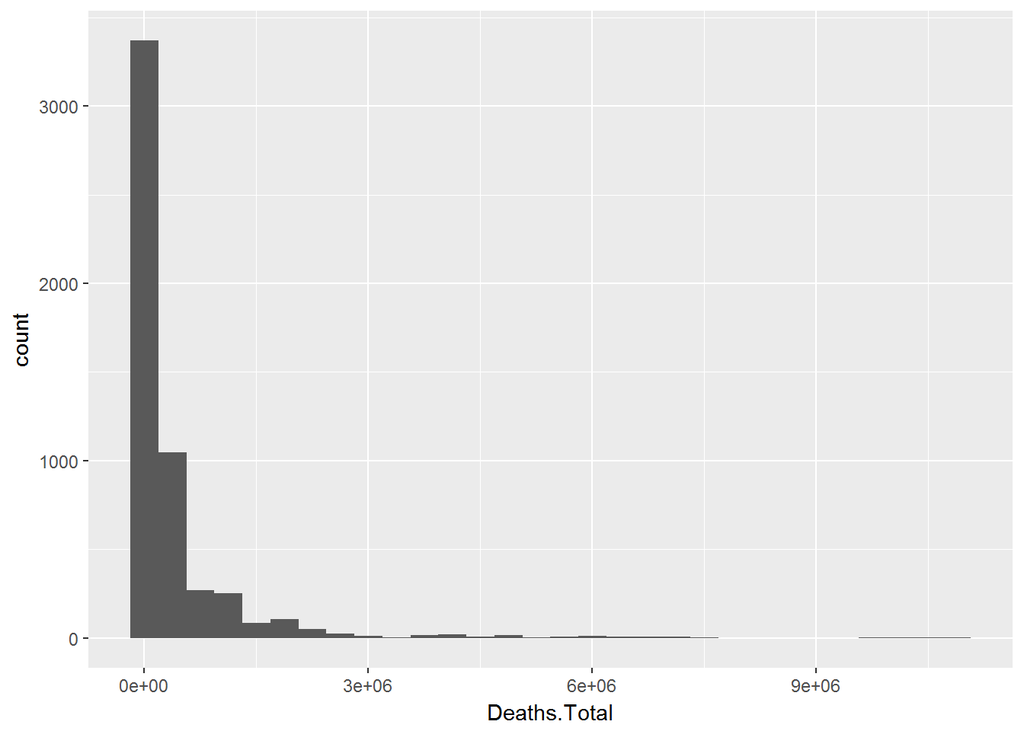

```r
usePackage('ggplot2')
#library(help = ggplot2)
#?qplot
#?ggplot

ggplot(reshaped, aes(x = Deaths.Total)) +
        geom_histogram()
```

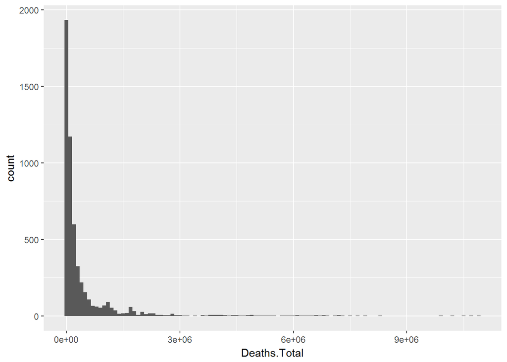

```r
ggplot(reshaped, aes(x = Deaths.Total)) +
        geom_histogram(binwidth = 100000)
```

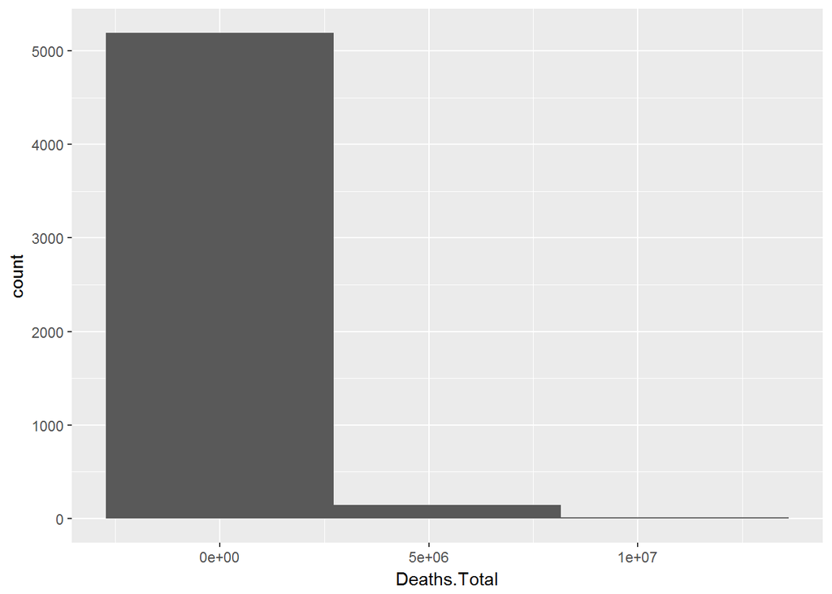

```r
ggplot(reshaped, aes(x = Deaths.Total)) +
        geom_histogram(bins = 3)
```

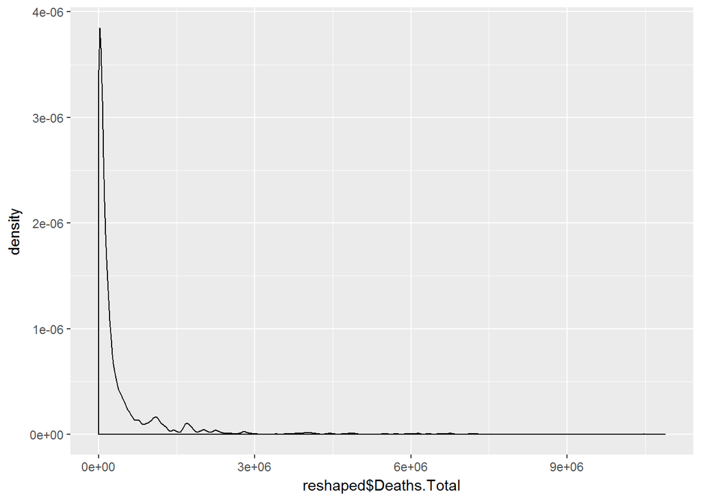

```r
qplot(reshaped$Deaths.Total, geom="density")
```

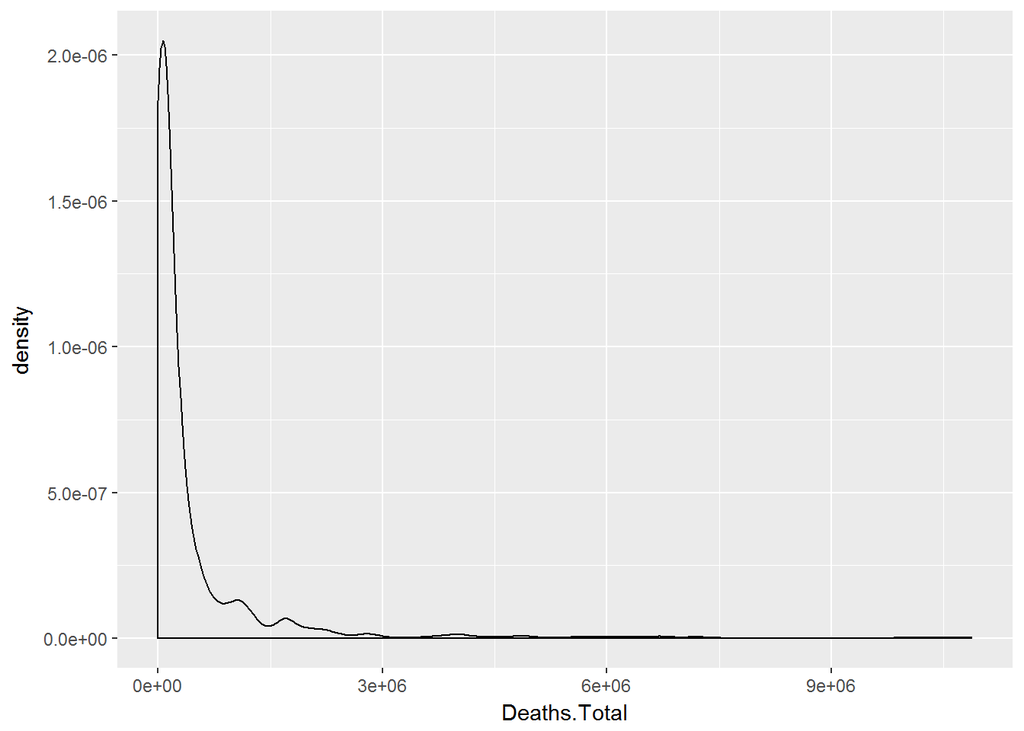

```r
ggplot(reshaped, aes(x = Deaths.Total)) +
        geom_density(adjust = 3)
```

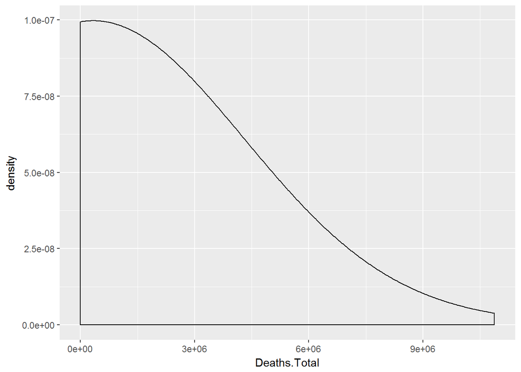

```r
ggplot(reshaped, aes(x = Deaths.Total)) +
        geom_density(adjust = 100)
```

5. How does the distribution look? Try transforming the variable and try to get it to look more normal (i.e., more Gaussian). If it already looks normal, do something to it to make it look non-normal.

```r
#The distribution is heavly skewed to the right. I will log it

reshaped$Deaths.Log <- log(reshaped$Deaths.Total)

head(reshaped)
```

```
##    Country Year Deaths.Male Deaths.Female Deaths.Unspecified Deaths.Total
## 1     1060 1980        2174          2388                 NA         4562
## 3     1060 2011        2966          2076                 NA         5042
## 5     1060 2012        2954          2574                 NA         5528
## 7     1125 1954      204202        196440                 NA       400642
## 9     1125 1955      215644        211500                 NA       427144
## 11    1125 1956      197736        187596                 NA       385332
##    Deaths.Log
## 1    8.425516
## 3    8.525558
## 5    8.617581
## 7   12.900824
## 9   12.964876
## 11  12.861861
```

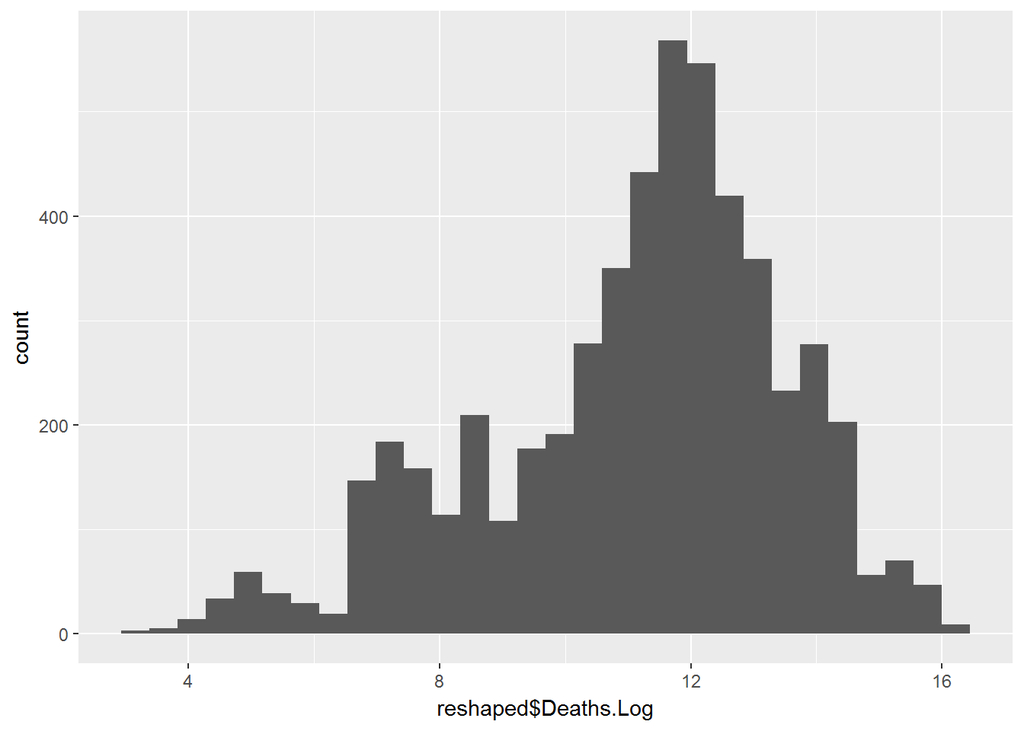

```r
qplot(reshaped$Deaths.Log, geom="histogram")
```

6. Is there a factor that you can use to break up this variable into groups of observations? If not, reshape your data so that there is, or create a factor if necessary. Then, do the following:
- Plot it as a density plot, mapping `color` to the factor
- Same, but try using `fill` instead of `color`
- Same, using `linetype` instead of `color`
- Plot the data as a boxplot, with the factor as `x` and the numerical variable as `y` HINT: use geom_boxplot

```r
#Reshape to add in (back) a factor for sex

usePackage('tidyr')

head(reshaped)
```

```
##    Country Year Deaths.Male Deaths.Female Deaths.Unspecified Deaths.Total
## 1     1060 1980        2174          2388                 NA         4562
## 3     1060 2011        2966          2076                 NA         5042
## 5     1060 2012        2954          2574                 NA         5528
## 7     1125 1954      204202        196440                 NA       400642
## 9     1125 1955      215644        211500                 NA       427144
## 11    1125 1956      197736        187596                 NA       385332
##    Deaths.Log
## 1    8.425516
## 3    8.525558
## 5    8.617581
## 7   12.900824
## 9   12.964876
## 11  12.861861
```

```r
gathered <- gather(reshaped, key = ID, value = Deaths, -Country, -Year)
head(gathered)
```

```
##   Country Year          ID Deaths
## 1    1060 1980 Deaths.Male   2174
## 2    1060 2011 Deaths.Male   2966
## 3    1060 2012 Deaths.Male   2954
## 4    1125 1954 Deaths.Male 204202
## 5    1125 1955 Deaths.Male 215644
## 6    1125 1956 Deaths.Male 197736
```

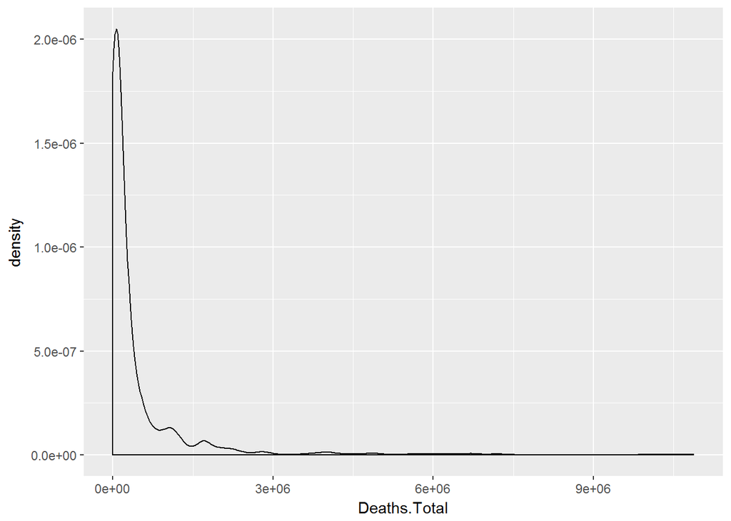

```r
ggplot(reshaped, aes(x = Deaths.Total)) +
        geom_density(adjust = 3)
```

7. Create a bar plot of the cell means of some variable. Steps:
- Find a numerical variable and a grouping factor (this can be the same as those chosen above).
- Get the mean value of the numerical variable, broken down by the factor.
- Plot this new aggregated data frame, using the “bar” geom.
8. Create a bar plot that gets means broken down by TWO grouping factors. For example, if Factor A has levels “red” and “blue” and Factor B has levels “north” and “south”, get the cell means of “red north”, “red south”, “blue north”, and “blue south.”
- Use the dplyr methods to get these means into a data frame format.
- Use the “bar” geom, but map the two variables to different graphical dimension. One should be the “x” value, but the other should be mapped to some other visual property.
9. Output all of the plots above (from problems 1-8) as a single PDF.
10. Is there a better type of visualization for your data? What numbers would you like to be able to visualize better? Be as explicit as possible, and write some “pseudo-code” to ilustrate what you think you would like.